# MS1 clustering with data censoring

MS1 data is inherently noisy. MS1 captures is not filtered (like DDA MS/MS). In addition, we aren’t matching spectra to peptides and thus are capturing **everything** in the sample, not just proteins.

What if we censored our MS1 data and only clustered the highest intensity values?

First we load the intensity data from our MS1. We identify quartiles in our data and consider different minimum values as missing in our data filtering step.

```r
load(here::here("data", "ms1int.RData"))
library(impute)
library(pvclust)
library(tidyverse)
library(DESeq2)
library(dendextend)
library(cluster)
### functions
is.nan.data.frame <- function(x){
    do.call(cbind, lapply(x, is.nan))}


filter_valids = function(df, conditions, min_count, at_least_one = TRUE) {
    # df = data frame containing LOG2 data for filtering and organized by data type
    # conditions = a character vector dictating the grouping
    # min_count = a numeric vector of the same length as "conditions" indicating the minimum
    #     number of valid values for each condition for retention
    # at_least_one = TRUE means to keep the row if min_count is met for at least one condition
    #     FALSE means min_count must be met across all conditions for retention
    #df[df==0] <- NA
    df[is.nan.data.frame(df)] <- 0
    all_names <- colnames(df)
    cond.names = lapply(conditions, # Group column names by conditions
                        function(x) grep(x, all_names, value = TRUE, perl = TRUE))
    cond.filter = sapply(1:length(cond.names), function(i) {
        df2 = df %>% dplyr::select(cond.names[[i]])   # Extract columns of interest
        df2 = as.matrix(df2)   # Cast as matrix for the following command
        sums = rowSums(df2!=0) # count the number of valid values for each condition
        sums >= min_count[i]   # Calculates whether min_count requirement is met
    })
    if (at_least_one) {
        df$KEEP = apply(cond.filter, 1, any)
    } else {
        df$KEEP = apply(cond.filter, 1, all)
    }
    #return(df) # No rows are omitted, filter rules are listed in the KEEP column

    return(df)  # only keeping rows that meet the criteria!
}

filter_valids_quart = function(df, conditions, min_count, int_remove, at_least_one = TRUE) {
    # df = data frame containing LOG2 data for filtering and organized by data type
    # conditions = a character vector dictating the grouping
    # min_count = a numeric vector of the same length as "conditions" indicating the minimum
    #     number of valid values for each condition for retention
    # at_least_one = TRUE means to keep the row if min_count is met for at least one condition
    #     FALSE means min_count must be met across all conditions for retention
    #df[df==0] <- NA
    df[is.nan.data.frame(df)] <- 0
    df[df <= int_remove] <- 0
    all_names <- colnames(df)
    cond.names = lapply(conditions, # Group column names by conditions
                        function(x) grep(x, all_names, value = TRUE, perl = TRUE))
    cond.filter = sapply(1:length(cond.names), function(i) {
        df2 = df %>% dplyr::select(cond.names[[i]])   # Extract columns of interest
        df2 = as.matrix(df2)   # Cast as matrix for the following command
        sums = rowSums(df2!=0) # count the number of valid values for each condition
        sums >= min_count[i]   # Calculates whether min_count requirement is met
    })
    if (at_least_one) {
        df$KEEP = apply(cond.filter, 1, any)
    } else {
        df$KEEP = apply(cond.filter, 1, all)
    }
    #return(df) # No rows are omitted, filter rules are listed in the KEEP column

    return(df)  # only keeping rows that meet the criteria!
}



## Cluster using top intensity qualtiles, top 2 quartiles, top 3 quatiles...etc
table(int_4_quartiles)
```

```
int_4_quartiles
remove    Low    Med   High
431383 431382 431383 431383
```

```r
int$quart <- int_4_quartiles
max_to_remove <- int %>% filter(quart == "remove")
max_to_remove <- max_to_remove$intensity %>% max()

high_min <- int %>% filter(quart == "High") %>%
    dplyr::select(intensity) %>% min()
med_min <- int %>% filter(quart == "Med") %>%
    dplyr::select(intensity) %>% min()
low_min <- int %>% filter(quart == "Low") %>%
    dplyr::select(intensity) %>% min()

print(high_min)
```

```
[1] 29190200
```

```r
print(med_min)
```

```
[1] 12626200
```

```r
## change everything that's below the minimum value of the quatile -> NA
## Then filter the same way as before
high_quart_int <- intensity
high_quart_int[high_quart_int < high_min] <- 0

med_quart_int <- intensity
med_quart_int[med_quart_int < med_min] <- 0
```

## Data filtering according the intensity quartiles.

```r
## Filter using this censored data
high_filt <- filter_valids(high_quart_int,
                               conditions = cond_opts,
                               min_count = cond_count,
                               at_least_one = T)
high_filt <- high_quart_int[high_filt$KEEP == 1,]  ## 12,014

med_filt <- filter_valids(med_quart_int,
                           conditions = cond_opts,
                           min_count = cond_count,
                           at_least_one = T)
med_filt <- med_quart_int[med_filt$KEEP == 1,]  ## 24,851


#### normalize by depth
high_norm <- estimateSizeFactorsForMatrix(high_filt)
high_norm <- sweep(high_filt, 2, high_norm, "/") ##peptides are normalized

med_norm <- estimateSizeFactorsForMatrix(med_filt)
med_norm <- sweep(med_filt, 2, med_norm, "/") ##peptides are normalized
```

## Missing data imputation

```r
## impute missing values
high_norm[high_norm== 0] <- NA
med_norm[med_norm== 0] <- NA


high_missing <- data.frame(num_missing = colSums(is.na(high_norm)),
                           total = rep(nrow(high_norm), ncol(high_filt))) %>%
    mutate(perc_missing = (num_missing/total) * 100)

high_imputed<- impute.knn(high_norm %>% as.matrix(), k = 10, rowmax = 0.5,
                          colmax = 0.96, rng.seed = 362436069)$data
```

```
4953 rows with more than 50 % entries missing;
 mean imputation used for these rows
```

[output not shown]

```r
high_imputed[high_imputed==0] <- 1
med_imputed<- impute.knn(med_norm %>% as.matrix(), k = 10, rowmax = 0.5,
                          colmax = 0.96, rng.seed = 362436069)$data
```

```
9618 rows with more than 50 % entries missing;
 mean imputation used for these rows
```

[output not shown]

```r
colnames(high_imputed) <- colnames(intensity)
colnames(med_imputed) <- colnames(intensity)
```

## Log2 transformation and fold change calculation

```r
# Transform by log2
high_log <- data.frame(high_imputed) %>%
    mutate_all(., funs(log2(.)))
```

[output not shown]

```r
colnames(high_log) = colnames(high_imputed)

med_log <- data.frame(med_imputed) %>%
    mutate_all(., funs(log2(.)))
colnames(med_log) = colnames(med_imputed)


## log fc
high_ctrl <- dplyr::select(high_log, contains("NC"))
high_ctrl$median = apply(high_ctrl, 1, median, na.rm = T)
high_drug_temp <- dplyr::select(high_log, -contains("NC"))
high_ctrl<- matrix(high_ctrl$median, nrow=length(high_ctrl$median),
                   ncol=ncol(high_drug_temp), byrow=F)
high_fc <- high_ctrl - high_drug_temp  %>% dplyr::select(noctrlmeta$Name)
#high_fc$feat_num <- rownames(high_filt)

med_ctrl <- dplyr::select(med_log, contains("NC"))
med_ctrl$median = apply(med_ctrl, 1, median, na.rm = T)
med_drug_temp <- dplyr::select(med_log, -contains("NC"))
med_ctrl<- matrix(med_ctrl$median, nrow=length(med_ctrl$median),
                   ncol=ncol(med_drug_temp), byrow=F)
med_fc <- med_ctrl - med_drug_temp %>% dplyr::select(noctrlmeta$Name)
#med_fc$feat_num <- rownames(med_filt)

#low_fc$feat_num <- rownames(low_filt)

#write.csv(high_fc %>% dplyr::select(noctrlmeta$Name), here::here("output", "ms1_openms_quart", "high_log2fc.txt"),
#          quote=F, row.names = T)
#write.csv(med_fc %>% dplyr::select(noctrlmeta$Name), here::here("output", "ms1_openms_quart", "med_log2fc.txt"),
#          quote=F, row.names = T)
```

## PCA of censored data

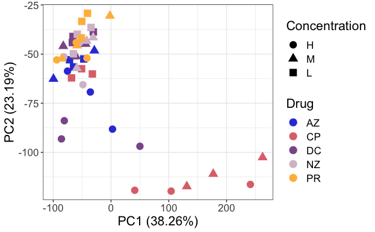

```r
###
high_pca <- prcomp(high_fc %>% t(), center=F, scale=F)
high_sampleVals<-data.frame(high_pca$x)
high_exprVals<-data.frame(high_pca$rotation)
high_PoV <- (high_pca$sdev^2/sum(high_pca$sdev^2))*100

high_coords<-data.frame(high_sampleVals, Drug = noctrlmeta$Drug,
                   samplename = rownames(high_sampleVals),
                   Concentration = noctrlmeta$Conc)
high_coords$Concentration <- factor(high_coords$Concentration, levels = c("H", "M", "L"))
high_numPCs <- 1:length(high_PoV)

for (i in 1:length(high_PoV)) {
    percent <- paste0("(", round(high_PoV[i],2), "%)")
    name <- paste0("PC", i, "per")
    assign(name, percent)
}

med_pca <- prcomp(med_fc %>% t(), center=F, scale=F)
med_sampleVals<-data.frame(med_pca$x)
med_exprVals<-data.frame(med_pca$rotation)
med_PoV <- (med_pca$sdev^2/sum(med_pca$sdev^2))*100

med_coords<-data.frame(med_sampleVals, Drug = noctrlmeta$Drug,
                        samplename = rownames(med_sampleVals),
                        Concentration = noctrlmeta$Conc)
med_coords$Concentration <- factor(med_coords$Concentration, levels = c("H", "M", "L"))
med_numPCs <- 1:length(med_PoV)

for (i in 1:length(med_PoV)) {
    percent <- paste0("(", round(med_PoV[i],2), "%)")
    name <- paste0("PC", i, "per")
    assign(name, percent)
}


quick_pca <- function(coords_df, x_PC, y_PC, PoV, shape, fill){
    yaxis <- y_PC
    xaxis <- x_PC
    yperc <- paste0("(", round(PoV[yaxis %>% as.numeric()] ,2), "%)")
    xperc <- paste0("(", round(PoV[xaxis %>% as.numeric()] ,2), "%)")

    yaxislabel <- paste0("PC", yaxis, " ", yperc)
    xaxislabel <- paste0("PC", xaxis, " ", xperc)
    pca_plot <- ggplot(coords_df, aes_string(x = paste0('PC', xaxis), y = paste0('PC', yaxis))) + #accept selectInput to choose axes!
        geom_point(size=4, aes_string(shape = shape, color = fill)) +
        #scale_color_manual(values=c("#3444DA",  "#FFBA49", "#8C5999", "#D7C0D0", "#363635", "#DF737A", "#20A39E", "#8EB8E5")) +
        scale_color_manual(values=c("#3444DA",  "#DF737A", "#8C5999", "#D7C0D0", "#FFBA49")) +
        scale_x_continuous(name=xaxislabel) + # labels depend on selected PCs
        scale_y_continuous(name=yaxislabel) +
        theme_bw() +
        theme(legend.position = "right", text=element_text(size=16))
    return(pca_plot)
}
(pc12high <- quick_pca(coords_df = high_coords, x_PC = 1, y_PC = 2, PoV=high_PoV, shape = "Concentration", fill = "Drug"))
```

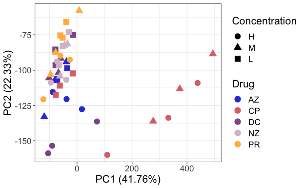

```r
#(pc23 <- quick_pca(coords_df = high_coords, x_PC = 2, y_PC = 3, shape = "Concentration", fill = "Drug"))
(pc12med <- quick_pca(coords_df = med_coords, x_PC = 1, y_PC = 2,  PoV=med_PoV, shape = "Concentration", fill = "Drug"))
```

## Clustering

Clustering can be completed the following scripts provided in `bin/`. The ICA implementation of precise-db requires a conda environment which can be accessed using `conda activate precise-db`.

This was explained in previous notebooks.

## Eigenfeature calculation and clustering

```r
highkmedoid_labels <- read.csv(here::here("data", "ms1_high", "k-med_labels.csv"), header=F) %>% as.vector()

medkmedoid_labels <- read.csv(here::here("data","ms1_med", "k-med_labels.csv"), header=F) %>% as.vector()

## clustering function
autoCluster <- function(fc_data, kmed_labels, fc_metadata, n_boot=100){
    clusterinfo <- kmed_labels %>% data.frame()
    highmax_clust <- kmed_labels %>% unique() %>% max()
    fc_clusters <- list()
    for (x in 0:highmax_clust){
        clustername <- paste("Cluster", x)
        y <- kmed_labels[which(clusterinfo$V1 == x),,drop=F] %>% rownames()
        fc_clusters[[clustername]] <- fc_data[y %>% as.numeric(),]
        fc_clusters[[clustername]]$feat_num <- y
    }
    #pca_clusters <- lapply(fc_clusters, function(x) prcomp(x %>% dplyr::select(-feat_num) %>% t(), center=T, scale=F)$x)
    #pc1_cluster <- lapply(pca_clusters,  "[", , 1)
    svd_clusters <- lapply(fc_clusters, function(x) svd(x %>% dplyr::select(-feat_num))$v)
# grabbing the first principal component
    svd1_cluster <- lapply(svd_clusters,  "[", , 1)
    clustereigengenes <- bind_cols(svd1_cluster) %>% data.frame()
    ### make a factored dataframe of the compounds
    fc_metadata <- fc_metadata %>% mutate(drug_conc = paste0(Drug, "-", Conc))
    datTraits <- data.frame(compounds= as.factor(fc_metadata$drug_conc))
    rownames(datTraits) <- fc_metadata$Name
    traits <- model.matrix(~ ., data=datTraits,
                           contrasts.arg = lapply(datTraits, contrasts, contrasts=FALSE))
    traits <- traits[,-1] ##removing intercept
    moduleTraitCor <- stats::cor(clustereigengenes, traits, method = "s")
    colnames(moduleTraitCor) <- colnames(moduleTraitCor) %>% substr(., 10, nchar(colnames(moduleTraitCor)))
    ###hclust clusters the rows
    module_clust <- hclust(as.dist(1-cor(t(moduleTraitCor), method="pearson")), method="average")
    treat_clust <- hclust(as.dist(1-cor(moduleTraitCor, method="pearson")), method="average")
    treat_clust_boot <- pvclust(moduleTraitCor, method.hclust="average",
                                method.dist="correlation", nboot=100,
                                iseed=2248)
    toreturn <- list("bootstrap" = treat_clust_boot, "cluster_order" = module_clust,
                     "cluster_cor" = moduleTraitCor)
    return(toreturn)
}

high_clustering <- autoCluster(high_fc, highkmedoid_labels, noctrlmeta)
```

```
Bootstrap (r = 0.5)... Done.
Bootstrap (r = 0.59)... Done.
Bootstrap (r = 0.69)... Done.
Bootstrap (r = 0.78)... Done.
Bootstrap (r = 0.88)... Done.
Bootstrap (r = 1.0)... Done.
Bootstrap (r = 1.09)... Done.
Bootstrap (r = 1.19)... Done.
Bootstrap (r = 1.28)... Done.
Bootstrap (r = 1.38)... Done.
```

```r
med_clustering <- autoCluster(med_fc, medkmedoid_labels, noctrlmeta)
```

```
Bootstrap (r = 0.47)... Done.
```

```
inappropriate distance matrices are omitted in computation: r =  0.473684210526316
```

```
Bootstrap (r = 0.58)... Done.
```

```
inappropriate distance matrices are omitted in computation: r =  0.578947368421053
```

```
Bootstrap (r = 0.68)... Done.
Bootstrap (r = 0.79)... Done.
Bootstrap (r = 0.89)... Done.
Bootstrap (r = 1.0)... Done.
Bootstrap (r = 1.05)... Done.
Bootstrap (r = 1.16)... Done.
Bootstrap (r = 1.26)... Done.
Bootstrap (r = 1.37)... Done.
```

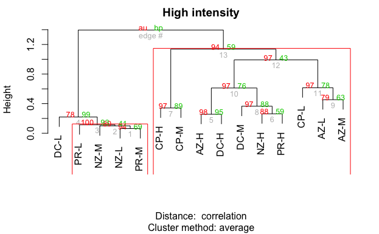

```r
high_clust_boot <- as.dendrogram(high_clustering$bootstrap)
high_clustering$bootstrap %>% plot(main = "High intensity")
high_clustering$bootstrap %>% pvrect(alpha=0.9, pv="au")
```

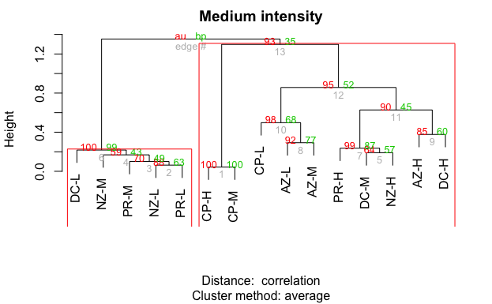

```r
med_clust_boot <- as.dendrogram(med_clustering$bootstrap)
med_clustering$bootstrap %>% plot(main = "Medium intensity")
med_clustering$bootstrap %>% pvrect(alpha=0.9, pv="au")
```

```r
NA
NA
```

Calculating “optimal” number of clusters for each dataset.

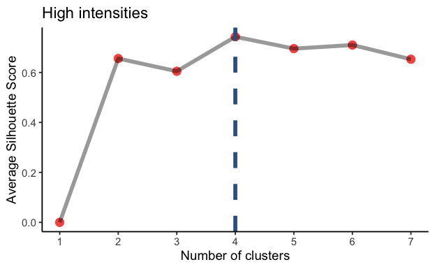

```r
quick_sil <- function(hclust_out, distance, max_k){
  silhouette_score <- function(i){
    k=cutree(hclust_out,i)
    ss <- silhouette(k, 1-cor(distance, method="pearson"))
    mean(ss[, 3])
    }
  clustnum <- 2:max_k
  avg_sil <- sapply(clustnum, silhouette_score)
  avg_sil <- data.frame(num = clustnum, sil_score = avg_sil)
  avg_sil <- rbind(c(1,0), avg_sil)
  return(avg_sil)
}

## High intensities
high_sil <- quick_sil(hclust_out=high_clustering$bootstrap, distance = 1-cor(high_clustering$cluster_cor, method="pearson"), max_k = 7)

(high_sil <- ggplot(high_sil, aes(x=num, y = sil_score)) +
  geom_point(size=4, colour="#F25C54", alpha=1) +
    geom_line(size=2, alpha=0.4) +
    geom_vline(xintercept=4, size = 2, linetype="dashed", color = "#38618C") +
    xlab("Number of clusters") +
    ylab("Average Silhouette Score") +
    scale_x_continuous(breaks = 1:30) +
    theme_classic(base_size=14) +
    ggtitle("High intensities")
)
```

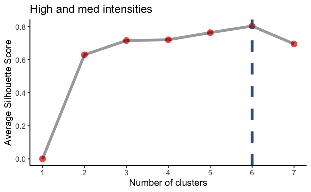

```r
## med intensities
med_sil <- quick_sil(hclust_out=med_clustering$bootstrap, distance = 1-cor(med_clustering$cluster_cor, method="pearson"), max_k = 7)

(med_sil <- ggplot(med_sil, aes(x=num, y = sil_score)) +
  geom_point(size=4, colour="#F25C54", alpha=1) +
    geom_line(size=2, alpha=0.4) +
    geom_vline(xintercept=6, size = 2, linetype="dashed", color = "#38618C") +
    xlab("Number of clusters") +
    ylab("Average Silhouette Score") +
    scale_x_continuous(breaks = 1:30) +
    theme_classic(base_size=14) +
    ggtitle("High and med intensities")
)
```

```r
NA
NA
NA
```

## Comparing clustering results

```r
clust_cols_med <- c("#DF737A", "#3444DA", "#59C9A5","#FFE66D", "#2E1F27", "#B892FF")
clust_cols_high <- c("#DF737A", "#3444DA", "#59C9A5","#FFE66D")

## ms1 optimal clust num = 2
high_svd <- high_clustering$bootstrap %>% as.dendrogram() %>% color_branches(k=4, col=clust_cols_high) %>%
    dendextend::set("branches_lwd", 3)
## ms1 optimal clust num = 2
med_svd <- med_clustering$bootstrap %>% as.dendrogram() %>% color_branches(k=6, col=clust_cols_med) %>%
    dendextend::set("branches_lwd", 3)
## ms1 optimal clust num = 2

compare_highmed <- dendlist(high_svd, med_svd) %>% untangle(method = "step2side")
compare_highmed %>% entanglement()
```

```
[1] 0.005756125
```

```r
cor_cophenetic(high_svd,med_svd)
```

```
[1] 0.9756385
```

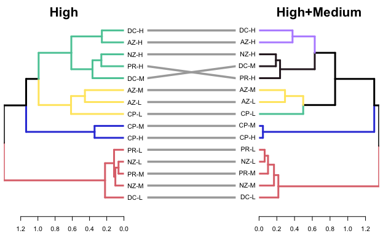

```r
#pdf(here::here("figs", "ms1_highmed_tanglegram.pdf"), width=6, height=5)
tanglegram(compare_highmed, sort=F, common_subtrees_color_lines=F,highlight_branches_lwd = F,
           highlight_distinct_edges=F, main_left="High", main_right="High+Medium")
```

```r
#dev.off()
```

Let’s compare our censored data to our original MS1 clusters

```r
pdf(here::here("figs", "ms1_high_tanglegram.pdf"), width=6, height=5)
tanglegram(compare_ms1_high , sort=F, common_subtrees_color_lines=F,highlight_branches_lwd = F,
           highlight_distinct_edges=F, main_left="MS1", main_right="MS1-High")
dev.off()
```

```r
compare_ms1_med <- dendlist(ms1_svd, med_svd) %>% untangle(method = "step2side")

compare_ms1_med  %>% entanglement()
```

```
[1] 0.060087
```

```r
pdf(here::here("figs", "ms1_med_svd_tanglegram.pdf"), width=6, height=5)
tanglegram(compare_ms1_med , sort=F, common_subtrees_color_lines=F,highlight_branches_lwd = F,
           highlight_distinct_edges=F, main_left="MS1", main_right="MS1-Med")
```

```r
dev.off()
```

Let’s also calculate a cophenetic correlation coefficient to compare high and medium intensity data to our full MS1 feature intensity data set.

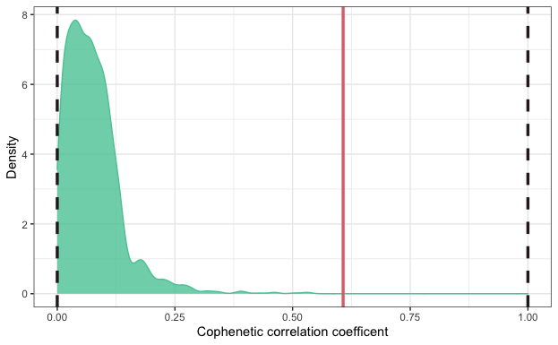